# Limits at Infinity: Horizontal Asymptotes

Yuanting Lu

09/02/2020

## Define Horizontal Asymptotes

We have learned how to read limits from a graph intuitively and identify horizontal asymptotes.

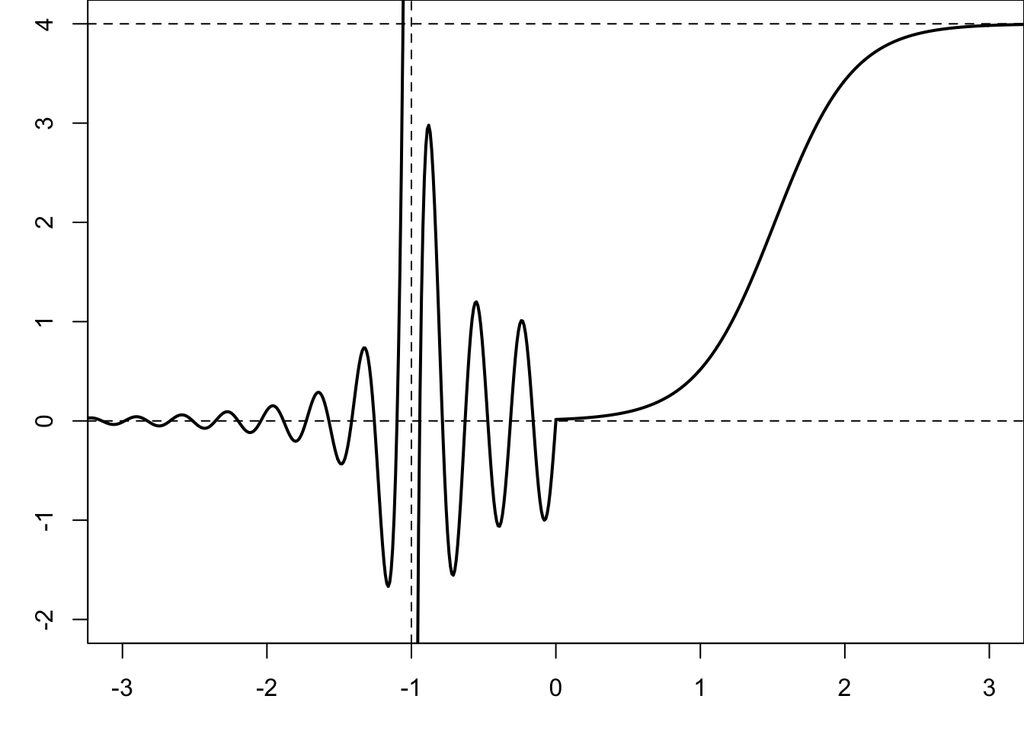

- $\displaystyle\lim_{x\to -\infty} f(x)=$
- $\displaystyle\lim_{x\to \infty} f(x)=$

How many horizontal asymptotes can we have in one graph? How about vertical asymptotes?

Using limits, how would you define a horizontal asymptote?

The line $y=L$ is a **horizontal asymptote** of the curve $y=f(x)$ if either
$$\displaystyle \lim_{x\to -\infty} f(x) = L \quad \mbox{ or }\quad \lim_{x\to \infty} f(x) = L.$$

## Evaluate Limits at Infinity

**Example 1.** $\displaystyle \lim_{x\to\infty} \dfrac{\sin x}{x}.$

**Example 2.** $\displaystyle \lim_{x\to\infty} \sin\left(\frac{1}{x}\right).$

**Example 3.** $\displaystyle \lim_{x\to\infty} e^{1/x}.$

**Example $\boldsymbol \pi$.** $\displaystyle \lim_{x\to \infty} \dfrac{2}{1 + e^{-x}}.$

**Example 4.** $\displaystyle \lim_{x\to - \infty} \dfrac{2}{1 + e^{-x}}.$

**Example 5.** $\displaystyle \lim_{x\to\infty} \dfrac{3 x^2 + x - 2}{5 x^2 + 4x + 1}.$

**Example 6.** $\displaystyle \lim_{x\to -\infty} \dfrac{2 - x + 5x^2}{ 3 x^2 + 1}.$

**Example 7.** $\displaystyle \lim_{x\to\infty} \dfrac{3 x^2 + x - 2}{x^3 + 1}.$

**Example 8.** $\displaystyle \lim_{x\to -\infty} \dfrac{x^3}{ (x-1)^2(x+1)^2}.$

**Example 9.** $\displaystyle \lim_{x\to \infty} \dfrac{\sqrt{2x^2 + 1}}{5x - 2}.$

**Example 10.** $\displaystyle \lim_{x\to -\infty} \dfrac{\sqrt{4x^2 - 1}}{2x + 3}.$

**Example 11.** $\displaystyle \lim_{x\to \infty} \left(\sqrt{x^2 + 1} - x\right).$

**Example 12.** $\displaystyle \lim_{x\to \infty} \left(\sqrt{4x^2 + x - 1} - 2x\right).$

**Example 13.** $\displaystyle \lim_{x\to \infty} \left(x^2 - 100x\right).$

**Example 14.** $\displaystyle \lim_{x\to -\infty} \left(\sqrt{x^2 + 1} + 3x\right).$

Verify your answers graphically.